# A tutorial to run diffdriver

# Environment requirement

Need 16G memory to run diffdriver. The place that need the most memory is for parameter estimation for background mutation rate.

# Prepare input

- Gene file

```r
genef = system.file("extdata", "example_gene.txt", package = "diffdriver")
head(read.table(genef, header = F))
```

```
#>       V1
#> 1   CHD4
#> 2 PIK3CA
```

- Mutation file

```r
mutf = system.file("extdata/", "example_mutations.txt", package = "diffdriver")
head(read.table(mutf, header = T))
```

```
#>   Chromosome  Position Ref Alt                     SampleID
#> 1         19  55653236   C   T TCGA-N6-A4VE-01A-11D-A28R-08
#> 2         17  65134211   C   T TCGA-NA-A4R1-01A-11D-A28R-08
#> 3         20  30354424   G   T TCGA-N8-A4PM-01A-11D-A28R-08
#> 4          6  18215312   G   C TCGA-N8-A4PO-01A-11D-A28R-08
#> 5          1 154186393   C   G TCGA-NA-A4R0-01A-11D-A28R-08
#> 6         10  23003128   C   A TCGA-NF-A4X2-01A-11D-A28R-08
```

- Phenotype file

Note: Nsyn is only required for when running diffdriver with mode “regular”. TODO: update regular BMR so that this is not used.

```r
phenof = system.file("extdata/", "example_phenotypes.txt", package = "diffdriver")
head(read.table(phenof, header = T))
```

```
#>                       SampleID SmokingCessation Nsyn
#> 1 TCGA-N5-A4R8-01A-11D-A28R-08        0.5319630    7
#> 2 TCGA-N5-A4RD-01A-11D-A28R-08        0.0448991    8
#> 3 TCGA-N5-A4RF-01A-11D-A28R-08       -0.3140750    7
#> 4 TCGA-N5-A4RJ-01A-11D-A28R-08        0.4229920    8
#> 5 TCGA-N5-A4RM-01A-11D-A28R-08       -0.2830070   12
#> 6 TCGA-N5-A4RN-01A-12D-A28R-08        0.7874080   14
```

- Background mutation file

TODO: add description about how to generate a background mutation file from driverMAPS output/ generate within diffdriver.

```r
bmrf = system.file("extdata/", "example_BMRlist.Rd", package = "diffdriver")
load(bmrf)
```

- Hotspot file

```r
hotf = system.file("extdata/", "example_hotspot.txt", package = "diffdriver")
head(read.table(hotf, header = T))
```

```
#>   chrom   start
#> 1 chr17 7577120
#> 2 chr17 7577538
#> 3 chr17 7577559
#> 4 chr17 7578271
#> 5 chr17 7578394
#> 6 chr17 7578406
```

- Directory that contains annotation files We have two types of annotations, one has 96 annotation files:

```r
annodir = "~/temp/annodir96"
list.files(annodir)
```

```
#>  [1] "TCGA-UCS"                       "TCGA-UCS_nttype10_annodata.txt"
#>  [3] "TCGA-UCS_nttype11_annodata.txt" "TCGA-UCS_nttype12_annodata.txt"
#>  [5] "TCGA-UCS_nttype13_annodata.txt" "TCGA-UCS_nttype14_annodata.txt"
#>  [7] "TCGA-UCS_nttype15_annodata.txt" "TCGA-UCS_nttype16_annodata.txt"
#>  [9] "TCGA-UCS_nttype17_annodata.txt" "TCGA-UCS_nttype18_annodata.txt"
#> [11] "TCGA-UCS_nttype19_annodata.txt" "TCGA-UCS_nttype1_annodata.txt"
#> [13] "TCGA-UCS_nttype20_annodata.txt" "TCGA-UCS_nttype21_annodata.txt"
#> [15] "TCGA-UCS_nttype22_annodata.txt" "TCGA-UCS_nttype23_annodata.txt"
#> [17] "TCGA-UCS_nttype24_annodata.txt" "TCGA-UCS_nttype25_annodata.txt"
#> [19] "TCGA-UCS_nttype26_annodata.txt" "TCGA-UCS_nttype27_annodata.txt"
#> [21] "TCGA-UCS_nttype28_annodata.txt" "TCGA-UCS_nttype29_annodata.txt"
#> [23] "TCGA-UCS_nttype2_annodata.txt"  "TCGA-UCS_nttype30_annodata.txt"
#> [25] "TCGA-UCS_nttype31_annodata.txt" "TCGA-UCS_nttype32_annodata.txt"
#> [27] "TCGA-UCS_nttype33_annodata.txt" "TCGA-UCS_nttype34_annodata.txt"
#> [29] "TCGA-UCS_nttype35_annodata.txt" "TCGA-UCS_nttype36_annodata.txt"
```

[output cut: 34 more lines]

One has 9 annotation files:

```r
annodir = "~/temp/annodir9"
list.files(annodir, pattern = "_annodata.txt")
```

```
#> [1] "nttype1_annodata.txt" "nttype2_annodata.txt" "nttype3_annodata.txt"
#> [4] "nttype4_annodata.txt" "nttype5_annodata.txt" "nttype6_annodata.txt"
#> [7] "nttype7_annodata.txt" "nttype8_annodata.txt" "nttype9_annodata.txt"
```

# Run diffdriver

```r
library(diffdriver)
outputdir <- "~/temp/output"
```

With signature adjustment, takes around 10min for two genes. Each additional gene will take 3-4 minutes. Please use the provide the annotation folder with 96 annotation files. `j` is the column that will be used as the phenotype, e.g j=2 means the second column in the phenotype file will be used as phenotype.

```r
res <- diffdriver(genef, mutf, phenof, bmrf, j = 2, hotf, annodir = "~/temp/annodir96", k=6, BMRmode = "signature", outputdir = outputdir, outputname = "testdiffdriver_sig")
```

```
#> [1] "Infer parameters in background mutation rate model, adjusting for inter individual mutational signature difference ..."
#> Initializing factors using Topic SCORE algorithm.
#> Initializing loadings by running 10 SCD updates.
#> Fitting rank-6 Poisson NMF to 52 x 81 dense matrix.
#> Running 100 EM updates, without extrapolation (fastTopics 0.6-158).
#> Refining model fit.
#> Fitting rank-6 Poisson NMF to 52 x 81 dense matrix.
#> Running 100 SCD updates, with extrapolation (fastTopics 0.6-158).
#> [1] "coding..."
#> [1] "processing ..."
#> [1] "for qnvars, filling in missing values ..."
#> [1] "for cvars (0/1 categories), filling in missing values ..."
#> [1] "normalizing categorical variables in annotation matrix ..."
#> [1] "Start to read in data for target genes ..."
#> [1] "coding..."
#> [1] "processing ..."
#> [1] "for qnvars, filling in missing values ..."
#> [1] "for cvars (0/1 categories), filling in missing values ..."
#> [1] "normalizing categorical variables in annotation matrix ..."
#> [1] "Start to process gene: CHD4"
#> [1] "Start to process gene: PIK3CA"
#> [1] "Finished."
```

```r
res
```

```
#>              dd.p      mlr.p   mlr.v2.p  fisher.p  binom.p      lr.p     dd.fdr
#> CHD4   1.00000000 0.85864512 0.83176808 1.0000000 1.000000 0.7509494 1.00000000
#> PIK3CA 0.04751203 0.01370322 0.01268792 0.5576717 0.453489 0.1443223 0.09502405
#>           mlr.fdr mlr.v2.fdr fisher.fdr binom.fdr    lr.fdr mut.E1 mut.E0 E1 E0
#> CHD4   0.85864512 0.83176808          1 1.0000000 0.7509494      5      4 22 18
#> PIK3CA 0.02740643 0.02537584          1 0.9069781 0.2886446      7      9 22 18
```

Without signature adjustment, takes around 5min for two genes. Each additional gene will take 2 minutes.Please use the provide the annotation folder with 9 annotation files.

```r
res <- diffdriver(genef, mutf, phenof, bmrf, j = 2, hotf, annodir = "~/temp/annodir9", BMRmode = "regular", outputdir = outputdir, outputname = "testdiffdriver_reg")
```

```
#> [1] "Start to read in data for target genes ..."
#> [1] "coding..."
#> [1] "processing ..."
#> [1] "for qnvars, filling in missing values ..."
#> [1] "for cvars (0/1 categories), filling in missing values ..."
#> [1] "normalizing categorical variables in annotation matrix ..."
#> [1] "Start to process gene: CHD4"
#> [1] "Start to process gene: PIK3CA"
#> [1] "Finished."
```

```r
res
```

```
#>              dd.p      mlr.p   mlr.v2.p  fisher.p  binom.p      lr.p     dd.fdr
#> CHD4   1.00000000 0.85864512 0.83176808 1.0000000 1.000000 0.7509494 1.00000000
#> PIK3CA 0.03061515 0.01370322 0.01268792 0.5576717 0.453489 0.1443223 0.06123031
#>           mlr.fdr mlr.v2.fdr fisher.fdr binom.fdr    lr.fdr mut.E1 mut.E0 E1 E0
#> CHD4   0.85864512 0.83176808          1 1.0000000 0.7509494      5      4 22 18
#> PIK3CA 0.02740643 0.02537584          1 0.9069781 0.2886446      7      9 22 18
```

# Plot specific genes

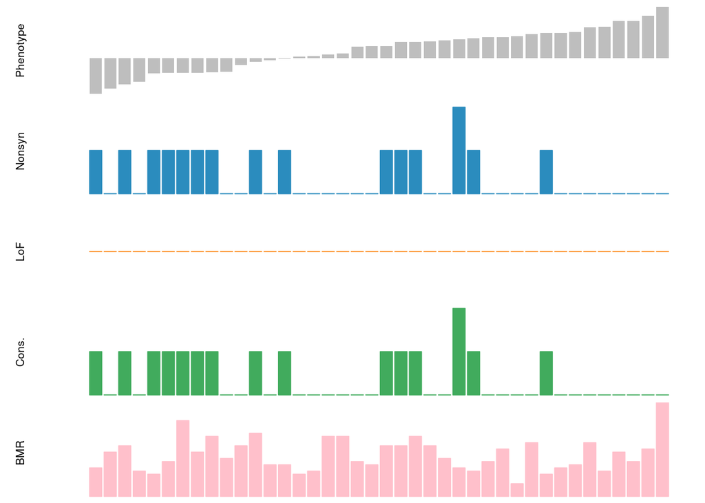

```r
load(file.path(outputdir,"testdiffdriver_reg_SmokingCessation_resdd.Rd"))     # load the output file from diffdriver.
g <- "PIK3CA" # only need to change gene name.
rig <- riallg[[g]]
rig$ridx <- 1:dim(rig)[1]
muts <- data.table::fread(mutf, header = T)
if (!grepl('chr', muts$Chromosome[1], fixed = T)) {muts$Chromosome <- paste0("chr",muts$Chromosome)}
muti <- na.omit(ci[rig[muts, on = c("chrom"= "Chromosome", "start" = "Position",  "ref" = "Ref",  "alt"= "Alt")], on = "SampleID"])
mutmtx <- Matrix::sparseMatrix(i = muti$ridx, j = muti$cidx, dims = c(max(rig$ridx), max(ci$cidx)))
bmrmtx= bmrallg[[g]]
ganno <- fannoallg[[g]]

diffdriver::plot_mut(mutmtx=mutmtx, canno=e, bmrmtx=bmrmtx, ganno=ganno)
```